# Data Analytics: Lebanese Disaster Relief Data

## Variable 33: Number with disaster related physical and permanent disability

- Remove negative values and replace with 0
- Replace outliers with 0
- Replace missing values with 0

```
------------------------------PRINT ALL AND TYPE-----------------------------------
-------------------------------RANGE OF VALUES---------------------------------------
MIN -1.0
MAX 24575.0
-------------------------NUMBER OF MISSING VALUES----------------------------------
6670
-------------------------PERCENT OF MISSING VALUES---------------------------------
0.20792418716294148
-------------------------DISTRIBUTION OF VALUES---------------------------------
```

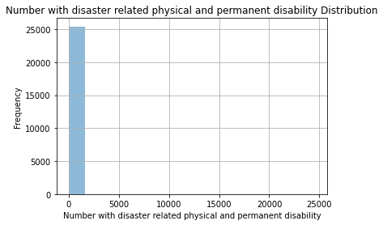

```python
inspect("Number with disaster related physical and permanent disability")
# Negative values ?
```

## Variable 34: Does any member of your family need immediate first aid support?

```
------------------------------PRINT ALL AND TYPE-----------------------------------
-------------------------------UNIQUE VALUES---------------------------------------
['no' nan 'yes']
---------------------------NUMBER OF UNIQUE VALUES---------------------------------
3
-------------------------NUMBER OF MISSING VALUES----------------------------------
2984
-------------------------PERCENT OF MISSING VALUES---------------------------------
0.09302035599613455
-------------------------DISTRIBUTION OF VALUES---------------------------------
```

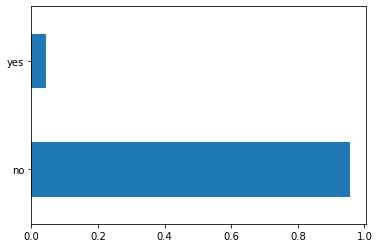

```python
#inspect("Does any member of your family need immediate first aid support?")
#Make lower
df["Does any member of your family need immediate first aid support?"] = toLowerCase(df, "Does any member of your family need immediate first aid support?")
inspect("Does any member of your family need immediate first aid support?")
```

## Variable 35, 36: Does any member of your family need chronic medications/healthcare? | How many members4

- Replace missing values in 'how many members4' column with 0

```
------------------------------PRINT ALL AND TYPE-----------------------------------
-------------------------------UNIQUE VALUES---------------------------------------
['yes' 'no' nan]
---------------------------NUMBER OF UNIQUE VALUES---------------------------------
3
-------------------------NUMBER OF MISSING VALUES----------------------------------
2631
-------------------------PERCENT OF MISSING VALUES---------------------------------
0.08201627232769101
-------------------------DISTRIBUTION OF VALUES---------------------------------
```

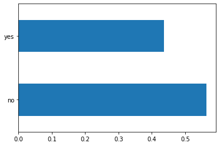

```python
inspect("Does any member of your family need chronic medications/healthcare?")
```

```
------------------------------PRINT ALL AND TYPE-----------------------------------
-------------------------------RANGE OF VALUES---------------------------------------
MIN 0.0
MAX 28.0
-------------------------NUMBER OF MISSING VALUES----------------------------------
7887
-------------------------PERCENT OF MISSING VALUES---------------------------------
0.24586177873375106
-------------------------DISTRIBUTION OF VALUES---------------------------------
```

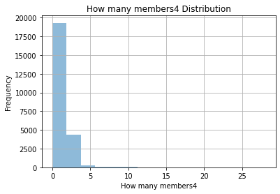

```python
inspect("How many members4")
```

## Variable 37: Do your family has access to healthcare or medication since the incident? | Why?

- Why needs to be given a score instead of categories. It seems this was a 'choose all that apply' questions
- Replace missing values in 'Why' with NaN (since they probably voted none to first question

```
------------------------------PRINT ALL AND TYPE-----------------------------------
-------------------------------UNIQUE VALUES---------------------------------------
['yes' 'none' 'partial' nan]
---------------------------NUMBER OF UNIQUE VALUES---------------------------------
4
-------------------------NUMBER OF MISSING VALUES----------------------------------
1672
-------------------------PERCENT OF MISSING VALUES---------------------------------
0.05212132547772686
-------------------------DISTRIBUTION OF VALUES---------------------------------
```

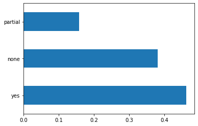

```python
#Make lower
df["Do your family has access to healthcare or medication since the incident?"] = toLowerCase(df, "Do your family has access to healthcare or medication since the incident?")
inspect("Do your family has access to healthcare or medication since the incident?")
```

```
------------------------------PRINT ALL AND TYPE-----------------------------------
-------------------------------UNIQUE VALUES---------------------------------------
[nan "can't_afford_it_financially"
 "can't_afford_it_financially,no/not_enough_healthcare_centers,denied_access_covid,no_transportation_available"
 'no/not_enough_healthcare_centers' 'family_doesnt_need_healthcare'
 "can't_afford_it_financially,family_doesnt_need_healthcare"
 "can't_afford_it_financially,no/not_enough_healthcare_centers"
 'no_transportation_available' 'denied_access_explosion'
 "can't_afford_it_financially,no_transportation_available"
 'no/not_enough_healthcare_centers,denied_access_covid'
 "can't_afford_it_financially,denied_access_covid" 'denied_access_covid'
 "no/not_enough_healthcare_centers,can't_afford_it_financially"
 "can't_afford_it_financially,no/not_enough_healthcare_centers,no_transportation_available"
 "denied_access_explosion,can't_afford_it_financially"
 "no_transportation_available,can't_afford_it_financially"
 "can't_afford_it_financially,denied_access_explosion"
 "can't_afford_it_financially,no_transportation_available,no/not_enough_healthcare_centers"
 "family_doesnt_need_healthcare,can't_afford_it_financially"
 'no/not_enough_healthcare_centers,no_transportation_available'
 "can't_afford_it_financially,no/not_enough_healthcare_centers,no_transportation_available,denied_access_explosion,family_doesnt_need_healthcare"
 "can't_afford_it_financially,no/not_enough_healthcare_centers,family_doesnt_need_healthcare"
 "denied_access_covid,can't_afford_it_financially"
 'family_doesnt_need_healthcare,no_transportation_available'
 'denied_access_explosion,no/not_enough_healthcare_centers'
 "can't_afford_it_financially,denied_access_covid,no/not_enough_healthcare_centers"
 'no/not_enough_healthcare_centers,denied_access_explosion'
 "can't_afford_it_financially,no/not_enough_healthcare_centers,no_transportation_available,denied_access_covid,denied_access_explosion,family_doesnt_need_healthcare"
 "no/not_enough_healthcare_centers,can't_afford_it_financially,no_transportation_available"
 'denied_access_covid,family_doesnt_need_healthcare'
 "can't_afford_it_financially,denied_access_covid,denied_access_explosion"
 "can't_afford_it_financially,no/not_enough_healthcare_centers,no_transportation_available,denied_access_covid"
 "denied_access_covid,denied_access_explosion,can't_afford_it_financially"
 "can't_afford_it_financially,no/not_enough_healthcare_centers,denied_access_covid"
 'denied_access_covid,no/not_enough_healthcare_centers'
 'family_doesnt_need_healthcare,denied_access_explosion'
 'family_doesnt_need_healthcare,no/not_enough_healthcare_centers'
 "no_transportation_available,can't_afford_it_financially,no/not_enough_healthcare_centers"
 'no_transportation_available,no/not_enough_healthcare_centers'
 "no/not_enough_healthcare_centers,no_transportation_available,can't_afford_it_financially"
 'no_transportation_available,family_doesnt_need_healthcare' 'Syrian'
 "can't_afford_it_financially,no/not_enough_healthcare_centers,denied_access_explosion"
 "can't_afford_it_financially,no_transportation_available,family_doesnt_need_healthcare"
 'no/not_enough_healthcare_centers,no_transportation_available,denied_access_explosion'
 'no/not_enough_healthcare_centers,family_doesnt_need_healthcare'
 'denied_access_covid,denied_access_explosion'
 'family_doesnt_need_healthcare,denied_access_covid'
 "can't_afford_it_financially,no_transportation_available,denied_access_explosion"
 "can't_afford_it_financially,denied_access_explosion,denied_access_covid"
 "can't_afford_it_financially,no/not_enough_healthcare_centers,no_transportation_available,denied_access_explosion"
 "can't_afford_it_financially,family_doesnt_need_healthcare,no/not_enough_healthcare_centers"]
---------------------------NUMBER OF UNIQUE VALUES---------------------------------
53
-------------------------NUMBER OF MISSING VALUES----------------------------------
15725
-------------------------PERCENT OF MISSING VALUES---------------------------------
0.49019607843137253
-------------------------DISTRIBUTION OF VALUES---------------------------------
```

[figure not shown]

```python
inspect("Why?")
# Since people can choose more than one option, its taking each combination of options as a different value
```

# WATER

## Variable 38: What is the source of cooking/drinking water since the incident?

- Values here need to be given a score instead of many options.

```
------------------------------PRINT ALL AND TYPE-----------------------------------
-------------------------------RANGE OF VALUES---------------------------------------
MIN 0.0
MAX 12.0
-------------------------NUMBER OF MISSING VALUES----------------------------------
1671
-------------------------PERCENT OF MISSING VALUES---------------------------------
0.052090152436173195
-------------------------DISTRIBUTION OF VALUES---------------------------------
```

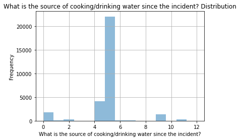

```python
df["What is the source of cooking/drinking water since the incident?"] = df["What is the source of cooking/drinking water since the incident?"].replace("Son of 12 ", np.nan)
lookupTable = {"none": 0, "mineral": 5, "unprotected": 1, "filtered": 4, "protected":2, "reservoir":3}
df["What is the source of cooking/drinking water since the incident?"] = scoreOptions(df, "What is the source of cooking/drinking water since the incident?", lookupTable)
inspect("What is the source of cooking/drinking water since the incident?")
# Since people can choose more than one option, its taking each combination of options as a different value
```

## Variable 39: What is the source of washing water?

- Values here need to be given a score instead of many options.

```
------------------------------PRINT ALL AND TYPE-----------------------------------
-------------------------------UNIQUE VALUES---------------------------------------
['public_filtered_water' 'purchased_mineral_water'
 'public_tank/reservoir,unprotected_well' 'protected_well' nan
 'public_tank/reservoir' 'public_filtered_water,protected_well'
 'public_tank/reservoir,public_filtered_water' 'unprotected_well' 'none'
 'purchased_mineral_water,public_tank/reservoir'
 'public_filtered_water,unprotected_well'
 'purchased_mineral_water,public_filtered_water'
 'public_filtered_water,purchased_mineral_water'
 'public_filtered_water,public_tank/reservoir'
 'protected_well,public_filtered_water'
 'protected_well,public_tank/reservoir'
 'purchased_mineral_water,protected_well'
 'public_tank/reservoir,purchased_mineral_water'
 'protected_well,purchased_mineral_water'
 'public_tank/reservoir,protected_well'
 'unprotected_well,public_tank/reservoir'
 'protected_well,public_filtered_water,public_tank/reservoir'
 'unprotected_well,purchased_mineral_water'
 'purchased_mineral_water,unprotected_well'
 'unprotected_well,public_filtered_water'
 'purchased_mineral_water,public_filtered_water,unprotected_well'
 'public_tank/reservoir,protected_well,public_filtered_water'
 'public_filtered_water,purchased_mineral_water,public_tank/reservoir'
 'purchased_mineral_water,public_tank/reservoir,public_filtered_water'
 'purchased_mineral_water,public_filtered_water,protected_well'
 'public_tank/reservoir,public_filtered_water,purchased_mineral_water'
 'unprotected_well,protected_well'
 'purchased_mineral_water,protected_well,public_tank/reservoir'
 'public_filtered_water,purchased_mineral_water,protected_well'
 'public_filtered_water,public_tank/reservoir,purchased_mineral_water'
 'public_tank/reservoir,protected_well,purchased_mineral_water'
 'public_filtered_water,unprotected_well,public_tank/reservoir'
 'purchased_mineral_water,public_filtered_water,public_tank/reservoir'
 'protected_well,public_filtered_water,purchased_mineral_water'
 'public_filtered_water,protected_well,unprotected_well'
 'public_filtered_water,protected_well,purchased_mineral_water'
 'purchased_mineral_water,public_filtered_water,protected_well,unprotected_well,public_tank/reservoir'
 'public_tank/reservoir,unprotected_well,public_filtered_water'
 'protected_well,unprotected_well'
 'public_filtered_water,public_tank/reservoir,protected_well'
 'purchased_mineral_water,protected_well,public_filtered_water'
 'public_tank/reservoir,purchased_mineral_water,protected_well'
 'protected_well,unprotected_well,public_tank/reservoir'
 'purchased_mineral_water,protected_well,unprotected_well']
---------------------------NUMBER OF UNIQUE VALUES---------------------------------
50
-------------------------NUMBER OF MISSING VALUES----------------------------------
1673
-------------------------PERCENT OF MISSING VALUES---------------------------------
0.05215249851928053
-------------------------DISTRIBUTION OF VALUES---------------------------------
```

[figure not shown]

```python
inspect("What is the source of washing water?")
# Since people can choose more than one option, its taking each combination of options as a different value
```

## Variable 40, 41: Is the water supply functioning in the apartment/ house? (Assuming functional prior to blast) | Why not?

- Missing values in why not to be replaced with NaN
- Give score to values in the 'why not' column

```
------------------------------PRINT ALL AND TYPE-----------------------------------
-------------------------------UNIQUE VALUES---------------------------------------
['yes' nan 'water_supply_not_functional_prior' 'no']
---------------------------NUMBER OF UNIQUE VALUES---------------------------------
4
-------------------------NUMBER OF MISSING VALUES----------------------------------
2629
-------------------------PERCENT OF MISSING VALUES---------------------------------
0.08195392624458368
-------------------------DISTRIBUTION OF VALUES---------------------------------
```

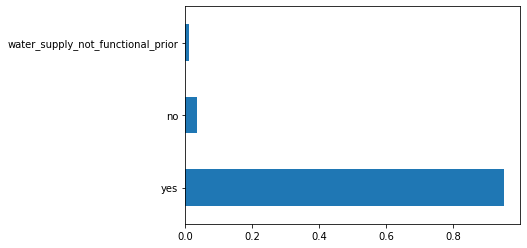

```python
#inspect("Is the water supply functioning in the apartment/ house? (Assuming functional prior to blast)")
#Make lower
df["Is the water supply functioning in the apartment/ house? (Assuming functional prior to blast)"] = toLowerCase(df, "Is the water supply functioning in the apartment/ house? (Assuming functional prior to blast)")
inspect("Is the water supply functioning in the apartment/ house? (Assuming functional prior to blast)")
```

```
------------------------------PRINT ALL AND TYPE-----------------------------------
-------------------------------RANGE OF VALUES---------------------------------------
MIN 1.0
MAX 4.0
-------------------------NUMBER OF MISSING VALUES----------------------------------
31072
-------------------------PERCENT OF MISSING VALUES---------------------------------
0.96860874715546
-------------------------DISTRIBUTION OF VALUES---------------------------------
```

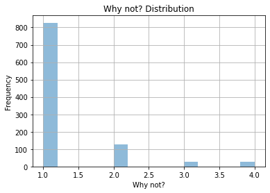

```python
lookupTable = {"pipes": 1, "basin": 1, "network": 1, "tanks":1 }
df["Why not?"] = scoreOptions(df, "Why not?", lookupTable)
inspect("Why not?")
# Since people can choose more than one option, its taking each combination of options as a different value
```

## Variable 42, 43, 44: What was the tank's capacity | Specify | your_place

- Not sure if these three columns are necessary
- Over 99% missing values in first two
- Not sure what 'your_place' means

```
------------------------------PRINT ALL AND TYPE-----------------------------------
-------------------------------UNIQUE VALUES---------------------------------------
[nan '2000' 'other' '500' '1000' '3000' '100' '5000' '4000' '1500' 1000
 '750']
---------------------------NUMBER OF UNIQUE VALUES---------------------------------
12
-------------------------NUMBER OF MISSING VALUES----------------------------------
31766
-------------------------PERCENT OF MISSING VALUES---------------------------------
0.990242837993703
-------------------------DISTRIBUTION OF VALUES---------------------------------
```

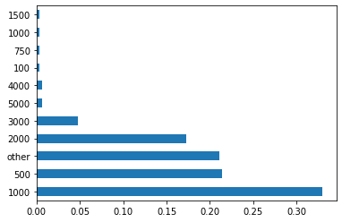

```python
uniqueVals = list(pd.unique(df["What was the tank's capacity"]))
for i in uniqueVals:
  if type(i) is str:
    df["What was the tank's capacity"]= df["What was the tank's capacity"].replace(i, i.split(" ")[0])
inspect("What was the tank's capacity")
```

```
------------------------------PRINT ALL AND TYPE-----------------------------------
-------------------------------UNIQUE VALUES---------------------------------------
[nan '100000' '300' '1600' 'no water tank' 'unknown' 'medium' 'shared'
 '10' 'طاقة شمسية']
---------------------------NUMBER OF UNIQUE VALUES---------------------------------
10
-------------------------NUMBER OF MISSING VALUES----------------------------------
32052
-------------------------PERCENT OF MISSING VALUES---------------------------------
0.999158327878051
-------------------------DISTRIBUTION OF VALUES---------------------------------
```

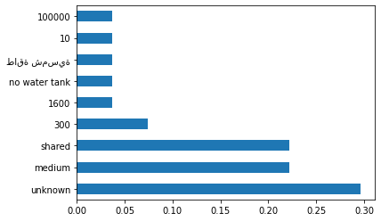

```python
#inspect("Specify")
#Spelling and make lower
df["Specify"] = toLowerCase(df, "Specify")
df["Specify"] = df["Specify"].replace('unknown ', 'unknown')
df["Specify"] = df["Specify"].replace('unkown', 'unknown')
inspect("Specify")
```

```
------------------------------PRINT ALL AND TYPE-----------------------------------
-------------------------------UNIQUE VALUES---------------------------------------
[nan 'no' 'yes']
---------------------------NUMBER OF UNIQUE VALUES---------------------------------
3
-------------------------NUMBER OF MISSING VALUES----------------------------------
28728
-------------------------PERCENT OF MISSING VALUES---------------------------------
0.8955391377536707
-------------------------DISTRIBUTION OF VALUES---------------------------------
```

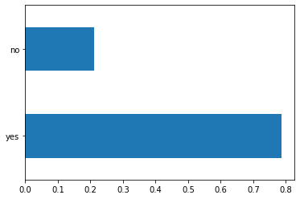

```python
inspect("your_place")
```

# HOUSE CONDITIONS

## Variable 45: What is your occupancy type

```
------------------------------PRINT ALL AND TYPE-----------------------------------
-------------------------------UNIQUE VALUES---------------------------------------
[nan 'Rented' 'Owned' 'Hosted']
---------------------------NUMBER OF UNIQUE VALUES---------------------------------
4
-------------------------NUMBER OF MISSING VALUES----------------------------------
6789
-------------------------PERCENT OF MISSING VALUES---------------------------------
0.21163377910782755
-------------------------DISTRIBUTION OF VALUES---------------------------------
```

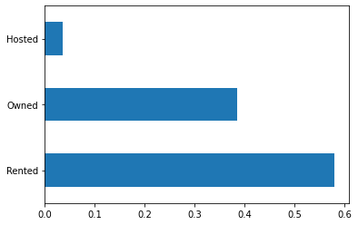

```python
inspect("What is your occupancy type")
```

## Variable 46: Are any of the following structural damages observed inside the apartment/ house?

- Values here need to be given a score instead of many options.

```
------------------------------PRINT ALL AND TYPE-----------------------------------
-------------------------------RANGE OF VALUES---------------------------------------
MIN 0.0
MAX 16.0
-------------------------NUMBER OF MISSING VALUES----------------------------------
2638
-------------------------PERCENT OF MISSING VALUES---------------------------------
0.08223448361856667
-------------------------DISTRIBUTION OF VALUES---------------------------------
```

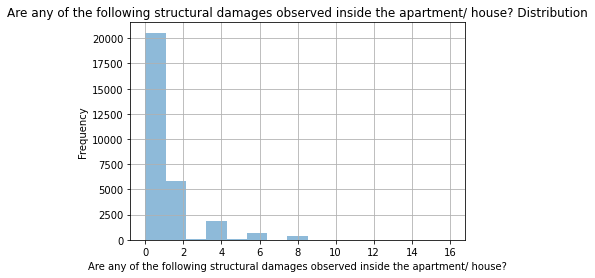

```python
lookupTable = {"none_of_the_above": 0, "windows": 1, "slab": 2, "walls": 2, "balcony(s)":2, "ceiling": 2,  "beams":2, "columns":2, "services":4, "amenities": 4, "destruction": 5 }
df["Are any of the following structural damages observed inside the apartment/ house?"] = scoreOptions(df, "Are any of the following structural damages observed inside the apartment/ house?", lookupTable)
# scoreOptionsList(df, "Are any of the following structural damages observed inside the apartment/ house?", lookupTable)
inspect("Are any of the following structural damages observed inside the apartment/ house?")
# Since people can choose more than one option, its taking each combination of options as a different value
```

## Variable 47: What is the condition of the EXTERNAL door(s)?

```
------------------------------PRINT ALL AND TYPE-----------------------------------
-------------------------------UNIQUE VALUES---------------------------------------
['no_damage_intact' 'minor_not_closable_repairable'
 'minor_closable_and_repairable' nan 'major_not_repairable_be_replaced'
 'not very good']
---------------------------NUMBER OF UNIQUE VALUES---------------------------------
6
-------------------------NUMBER OF MISSING VALUES----------------------------------
2984
-------------------------PERCENT OF MISSING VALUES---------------------------------
0.09302035599613455
-------------------------DISTRIBUTION OF VALUES---------------------------------
```

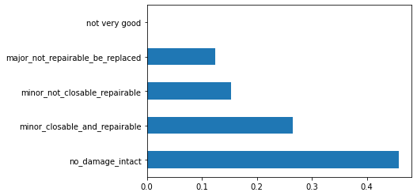

```python
inspect("What is the condition of the EXTERNAL door(s)?")
```

## Variable 48: What are the conditions of windows?

- Here we assigned scores to values:
- no damage was given a score of 0, damaged glass or frames a score of 1m and fully broken or damaged a score of 2
- So a lower score means less damage and vice versa

```
------------------------------PRINT ALL AND TYPE-----------------------------------
-------------------------------RANGE OF VALUES---------------------------------------
MIN 0.0
MAX 2.0
-------------------------NUMBER OF MISSING VALUES----------------------------------
2984
-------------------------PERCENT OF MISSING VALUES---------------------------------
0.09302035599613455
-------------------------DISTRIBUTION OF VALUES---------------------------------
```

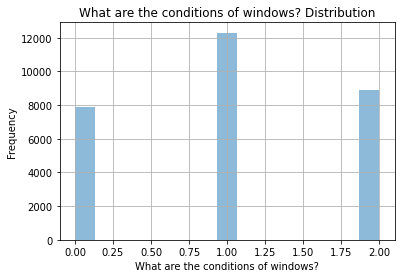

```python
lookupTable = {"no_damage_intact": 0, "glass": 1, "frames": 1, "broken damaged": 2}
df["What are the conditions of windows?"] = scoreOptions(df, "What are the conditions of windows?", lookupTable)
inspect("What are the conditions of windows?")
# Since people can choose more than one option, its taking each combination of options as a different value
#Different window parts are assigned the same weight
```

## Variable 49: Have external openings been sealed off using temporary material (e.g plastic sheeting and timber)?

```
------------------------------PRINT ALL AND TYPE-----------------------------------
-------------------------------UNIQUE VALUES---------------------------------------
['yes' 'no' nan]
---------------------------NUMBER OF UNIQUE VALUES---------------------------------
3
-------------------------NUMBER OF MISSING VALUES----------------------------------
2986
-------------------------PERCENT OF MISSING VALUES---------------------------------
0.09308270207924187
-------------------------DISTRIBUTION OF VALUES---------------------------------
```

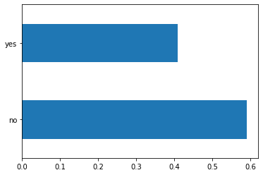

```python
inspect("Have external openings been sealed off using temporary material (e.g plastic sheeting and timber)?")
```

## Variable 50: Toilet condition

- We can also assign scores of damage here

```
------------------------------PRINT ALL AND TYPE-----------------------------------
-------------------------------UNIQUE VALUES---------------------------------------
['acceptable' nan 'Unacceptable_black_water_leakage'
 'unacceptable_broken_hardware' 'unacceptable']
---------------------------NUMBER OF UNIQUE VALUES---------------------------------
5
-------------------------NUMBER OF MISSING VALUES----------------------------------
1674
-------------------------PERCENT OF MISSING VALUES---------------------------------
0.05218367156083419
-------------------------DISTRIBUTION OF VALUES---------------------------------
```

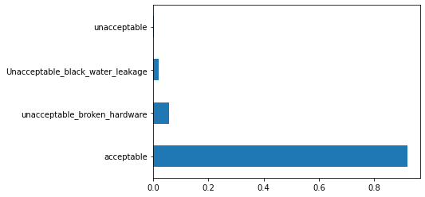

```python
df["Toilet condition"] = df["Toilet condition"].replace('gd', 'acceptable')
inspect("Toilet condition")
```

# INCOME/ FINANCES

## Variable 51: How many members generated income in the last 2 weeks

- We have to remove outliers here

```
------------------------------PRINT ALL AND TYPE-----------------------------------
-------------------------------RANGE OF VALUES---------------------------------------
MIN 0.0
MAX 40000000.0
-------------------------NUMBER OF MISSING VALUES----------------------------------
78
-------------------------PERCENT OF MISSING VALUES---------------------------------
0.0024314972411858225
-------------------------DISTRIBUTION OF VALUES---------------------------------
```

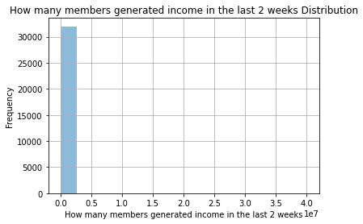

```python
#Negative values
df["How many members generated income in the last 2 weeks"]=df["How many members generated income in the last 2 weeks"].replace(-1, np.nan)
inspect("How many members generated income in the last 2 weeks")
```

## Variable 52: What is the total income generated on monthly basis

- Remove outliers

```
------------------------------PRINT ALL AND TYPE-----------------------------------
-------------------------------RANGE OF VALUES---------------------------------------
MIN 0.0
MAX 2100000303.0
-------------------------NUMBER OF MISSING VALUES----------------------------------
1697
-------------------------PERCENT OF MISSING VALUES---------------------------------
0.05290065151656847
-------------------------DISTRIBUTION OF VALUES---------------------------------
```

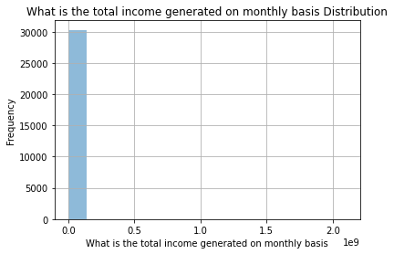

```python
inspect("What is the total income generated on monthly basis")
```

## Variable 53, 54: Do you have any saving? | How much?

- Many missing values here. Does that mean no or refuse to answer?
- Remove outliers in 'How much' column

```
------------------------------PRINT ALL AND TYPE-----------------------------------
-------------------------------UNIQUE VALUES---------------------------------------
[nan 'no' 'yes' 'refuse to answer ']
---------------------------NUMBER OF UNIQUE VALUES---------------------------------
4
-------------------------NUMBER OF MISSING VALUES----------------------------------
25689
-------------------------PERCENT OF MISSING VALUES---------------------------------
0.8008042644720845
-------------------------DISTRIBUTION OF VALUES---------------------------------
```

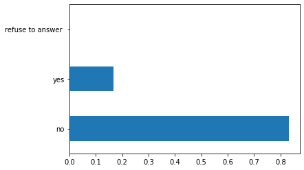

```python
df["Do you have any saving?"] = toLowerCase(df, "Do you have any saving?")
inspect("Do you have any saving?")
# Make lower
```

```
------------------------------PRINT ALL AND TYPE-----------------------------------
-------------------------------RANGE OF VALUES---------------------------------------
MIN 0.0
MAX 1000000000.0
-------------------------NUMBER OF MISSING VALUES----------------------------------
6042
-------------------------PERCENT OF MISSING VALUES---------------------------------
0.18834751706724026
-------------------------DISTRIBUTION OF VALUES---------------------------------
```

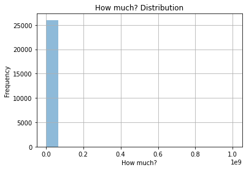

```python
inspect("How much?")
```

## Variable 55, 56: Did you receive any assistance since the incident | What type of assistance?

- Do missing values here mean no?
- Replace 'what type of assistance' with categories or scores

```
------------------------------PRINT ALL AND TYPE-----------------------------------
-------------------------------UNIQUE VALUES---------------------------------------
['yes' nan 'no']
---------------------------NUMBER OF UNIQUE VALUES---------------------------------
3
-------------------------NUMBER OF MISSING VALUES----------------------------------
23084
-------------------------PERCENT OF MISSING VALUES---------------------------------
0.7195984912247888
-------------------------DISTRIBUTION OF VALUES---------------------------------
```

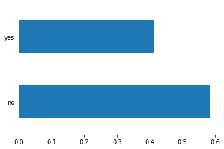

```python
df["Did you receive any assistance since the incident"] = toLowerCase(df, "Did you receive any assistance since the incident")
inspect("Did you receive any assistance since the incident")
#Make lower
```

```
------------------------------PRINT ALL AND TYPE-----------------------------------
-------------------------------UNIQUE VALUES---------------------------------------
['food' 'none'
 'food,cash,water,clothes_and_shoes,transport,community_and_psychosocial'
 nan 'other' 'water' 'food,shelter' 'food,water' 'cash'
 'infant_formula_baby_food,food' 'infant_formula_baby_food,water,cash'
 'infant_formula_baby_food' 'food,cash' 'shelter' 'cash,food'
 'food,infant_formula_baby_food' 'cash,food,infant_formula_baby_food'
 'cash,food,water' 'food,cash,water' 'infant_formula_baby_food,other'
 'clothes_and_shoes' 'food,cash,shelter,transport'
 'food,cash,shelter,clothes_and_shoes'
 'food,cash,shelter,community_and_psychosocial' 'shelter,food,cash,other'
 'cash,shelter' 'food,water,other' 'food,cash,shelter'
 'food,cash,shelter,other' 'food,cash,water,community_and_psychosocial'
 'food,other' 'food,clothes_and_shoes' 'food,cash,shelter,water'
 'food,cash,clothes_and_shoes' 'shelter,cash' 'food,cash,other'
 'cash,food,shelter' 'shelter,cash,food' 'shelter,food,cash'
 'food,cash,shelter,clothes_and_shoes,transport' 'cash,food,shelter,other'
 'clothes_and_shoes,cash' 'other,food' 'community_and_psychosocial'
 'food,cash,water,infant_formula_baby_food'
 'infant_formula_baby_food,cash,food,transport,water,community_and_psychosocial'
 'food,cash,clothes_and_shoes,infant_formula_baby_food' 'other,cash'
 'shelter,food'
 'cash,food,shelter,community_and_psychosocial,clothes_and_shoes'
 'food,cash,clothes_and_shoes,transport'
 'community_and_psychosocial,cash,food'
 'food,cash,community_and_psychosocial'
 'food,cash,transport,clothes_and_shoes,community_and_psychosocial,water,shelter'
 'infant_formula_baby_food,cash,food' 'infant_formula_baby_food,food,cash'
 'food,cash,infant_formula_baby_food' 'cash,food,clothes_and_shoes'
 'cash,other,shelter,clothes_and_shoes,food'
 'food,clothes_and_shoes,other,shelter'
 'food,cash,clothes_and_shoes,water' 'food,transport,clothes_and_shoes'
 'food,cash,shelter,transport,clothes_and_shoes'
 'food,infant_formula_baby_food,cash' 'cash,food,other'
 'food,cash,shelter,other,community_and_psychosocial'
 'food,cash,shelter,infant_formula_baby_food,clothes_and_shoes'
 'food,shelter,cash,other' 'cash,shelter,food' 'food,shelter,cash'
 'cash,food,shelter,infant_formula_baby_food'
 'food,shelter,cash,clothes_and_shoes' 'water,food,cash' 'water,food'
```

[output cut: 141 more lines]

```
 'shelter,food,water,clothes_and_shoes,community_and_psychosocial,cash,infant_formula_baby_food'
 'other,food,cash,shelter' 'food,transport,cash'
 'cash,infant_formula_baby_food,clothes_and_shoes,community_and_psychosocial'
 'infant_formula_baby_food,cash,food,shelter' 'cash,food,family_tracing'
 'transport,food' 'other,infant_formula_baby_food'
 'food,water,cash,clothes_and_shoes,community_and_psychosocial,shelter,transport'
 'community_and_psychosocial,other' 'food,other,shelter'
 'shelter,infant_formula_baby_food']
---------------------------NUMBER OF UNIQUE VALUES---------------------------------
283
-------------------------NUMBER OF MISSING VALUES----------------------------------
7739
-------------------------PERCENT OF MISSING VALUES---------------------------------
0.2412481685838087
-------------------------DISTRIBUTION OF VALUES---------------------------------
```

[figure not shown]

```python
inspect("What type of assistance?")
# Since people can choose more than one option, its taking each combination of options as a different value
```

## Variable 57, 58: Can you estimate how many days your current income, savings and assets can sustain your needed minimum expenditures without additional help? | How many?

- Remove this column?
- Or we can replace with Yes/no? Many of these answers belong in the column after (57 in 58).
- Remove negative values and outliers in Variable 58.

```python
#inspect("Can you estimate how many days your current income, savings and assets can sustain your needed minimum expenditures without additional help?")
# Spellings and language
```

```python
replacement_bags_pairs = {"no": set(['كلا', 'No', 'X', 'لا', 'Ma bta3rif', 'لا٠', 'كلا ', 'غير معروف', 'No.', 'No ']),
                          "day by day": set(['day by day ', 'live everyday and its day ', 'All','O', 'حسب يوم بيوم', 'كل يوم بيوم ', ]),
                          "No help needed": set(['ولا يوم', 'merteh so far', 'No', 'No financial help needed', 'No need for assistance ', 'No need for help', 'Nothing ', 'Nothing', 'none', 'None']),
                          np.nan : set(['na']),
                          "always": set(['Always', 'كل الايام', 'All']),
                          "yes": set(['Yes ', 'Yes I can ', 'Yed', 'Yea', 'yee', 'Yes', 'نعن'])

                          }

for replacement in replacement_bags_pairs.keys():
  wordBag = replacement_bags_pairs[replacement]
  df["Can you estimate how many days your current income, savings and assets can sustain your needed minimum expenditures without additional help?"] = replaceWordSet(df, "Can you estimate how many days your current income, savings and assets can sustain your needed minimum expenditures without additional help?", wordBag, replacement)
```

```
------------------------------PRINT ALL AND TYPE-----------------------------------
-------------------------------UNIQUE VALUES---------------------------------------
[nan 'no' 'yes' 'refuse_to_answer' 'Between 14 and 30 days'
 'Less than 7 days' 'No help needed' 'Relatives send money usually ' 60
 'عشرة ايام' '6 days ' 'اقل من شهر' 'day by day' 'اسبوع'
 'More than 365 days' 4 'between 14 and 30 days' 'whole month' 'Cash'
 'sustainable' 'نعم' 'طعام و شراب' 'شهر' 'one week' 9 '٤ شهور ' 'شهر كامل'
 'لا يوجد مدخول ' 3 'الشهر كامل' 'عشرة أيام' 'One week' '٣ شهور '
 'كل الشهر' '4 months' 'لا يوجد دخل اخر 6 اشهر كلو بالدين' 'كل يوم بيومه'
 'food' 'month' 'لا يمكن الصمود' '6 شهور' 'one month' 'سنة'
 "he lost all his savings reparing the house, he's living on his current salary"
 'ليس كافيا' 'Electronics' 'Private' 'Food' 'لا يوجد دخل حاليا' 'لامال'
 'More than 1 year' 'Always recieving assistance' 'شهرين' 'لا يوجد مدخرات'
 'اقساط الجامعات ' 'اقل من جمعة' 'One month' 'Few weeks' 'عشر ايام'
 'Less_than_14_days' 'Few months' 'طالما يعمل الاولاد' 'Month' 'غير محدد'
 '4 days' 'Half of the month' 'Till winter' 43894 'ممكن' 'ايام١٠'
 'Less than a month' 'رفض الاجابة' 'لا يوجد' 'تكفي لعشر ايام'
 'More than a month ' '     ' 'Less than 10 days ' 'Whole month'
 'Monthly ' 'Cant handle' 'always' 'لا يوجد مال حالياً' 'Barely '
 'يلبي احتياجات' 'Whole month ' 'يكفي شهريا' 'ايام' 'One month '
 'Few weeks ' 'اشهر' 'Less than 10 days' 'One week max']
---------------------------NUMBER OF UNIQUE VALUES---------------------------------
92
-------------------------NUMBER OF MISSING VALUES----------------------------------
2443
-------------------------PERCENT OF MISSING VALUES---------------------------------
0.0761557405156021
-------------------------DISTRIBUTION OF VALUES---------------------------------
```

[figure not shown]

```python
inspect("Can you estimate how many days your current income, savings and assets can sustain your needed minimum expenditures without additional help?")
```

```
------------------------------PRINT ALL AND TYPE-----------------------------------
-------------------------------RANGE OF VALUES---------------------------------------
MIN -30.0
MAX 450000000.0
-------------------------NUMBER OF MISSING VALUES----------------------------------
25641
-------------------------PERCENT OF MISSING VALUES---------------------------------
0.7993079584775087
-------------------------DISTRIBUTION OF VALUES---------------------------------
```

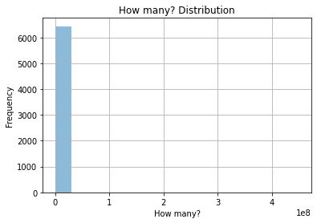

```python
inspect("How many?")
#What does this mean
#Negative values
```

# BASIC NEEDS

## Variable 59 - 65: What are the basic needs you will have the most difficulties meeting in the coming 7 days (Rank 1st, 2nd and 3rd)?

- We need to replace these with specific categories. Or we can divide into three main categories and so three columns: food, medicine, housing?

```
------------------------------PRINT ALL AND TYPE-----------------------------------
-------------------------------UNIQUE VALUES---------------------------------------
[nan 'الطعام' 'المال' 'Food and electric maintenance ' 'N/a' 'Food' 'Na'
 'Money' 'Medication, meat, and other goods' 'Nothing'
 '1-Rent 2- food assistance '
 '1-Rent 2- Food assistance - 3-diapers and milk'
 '1-medications 2-food asiatance 3- medical support'
 '1-Medications 2- food assisstance ' '1-Rent 2- food assistance -Milk '
 '1-Travel 2-rent-food assistance' 'ادوية، مازوت، مواد تنظيف، '
 'Medicine , food, water ' 'تامين الدواء' 'Rent for house'
 'علاج فزيائي للطفل، اجار بيت' 'Rent for house, food, medicals'
 '1. Rent  2nd health 3rd food' 'Rent of the house, food, medical'
 'Rent, medicals' 'Medicals, electricity payment'
 'Health and food and rent' '1st' '3rd' '2nd'
 'المسكن ، المصروف ، الأكل ، الملابس' 'المسكن ، الطبابة' 'المسكن'
 'المسكن ، الملبس ، المصروف' 'المسكن ، المأكل ، المصروف'
 'أجار المسكن ، المصروف ، المأكل' 'الأكل ، المسكن ، الملابس'
 'أجار المنزل ، المصروف ، المأكل' 'لا شيئ' 0 'لا حاجة ' '.' 'Yes'
 'مواد غذائية' 'المواد الغيذائية' 'صحية' 'لا شيء' 'X' '..' 'الزجاج' 1
 'Cash' 'Milk' 'لا جواب' 'مال' 'Z' 'no' 'Nutrition ' 'cash' 'ادوية'
 'تصليح' 'لا' '-' 'ا' 'اصلاح النوافذ' 2 'المواد الغيذاذية و اغراض الطفل'
 'المواد الغيذاذية والادوية ' 'مواد غذائية و ادوية و مواد تنظيف'
 'المواد الغيذائية والادوية والمواد التنضيف' 'المواد الغذائية والادوية'
 'No' 'التصليح' 'طعام' 'لا صعوبة' 'kahraba,may....' 'No difficulties'
 'Yes ' 'الاولى' ',' 'الأدوية' 'الاكل' 'ادوية ' 'المدارس ' 'None'
 'مواد غزائية والادوية' 'Medicine' 'ترميم' 'مواد غذائية مواد تنظيف' 'Rent'
 'اصلاح النوافذ ' 'الطبابة' 'دواء مواد غذائية'
 'مواد الغيذائية والمواد التنديف' 'اجار0' 'لا يوجد' 'Tosli7 2zez' 'Tosli7'
 'لا احتياجات' 'امور الأولاد' 'مواد غيذائية وادوية'
 'مواد غذائية مياه ادوات تنظيف' 'food,money,medicament,water'
 'money,food,medicament' 'الوضع المادي جيد'
 'مواد التنظيف الاكثر استعمالاً' 'تصليح الشبابيك والابواب'
 'مال-دواء-تصليح زجاج' 'مال-دواء-تصليح رجاج' 'اصلاحات'
 'غذاء الأمن السيولة تعليم' 'زجاج-ادوية-مال' 'yes' 'الصحة' 'دواء'
 'الغذاء السيولة مأوى' 'شبابيك' 'تصليح الشبابيك'
 'مواد غذائية/ مواد التنظيف' 'حليب اطفال' 'Services' 'الأمن السيولة غذاء'
 'نعم' 'Tosli7 l2zez ' 'Food ' 'Shelter' 'Foods ' 'Hdksme' 'Maintenance '
 'دواء، تصليح المأوى' 'اكل أجار ' 'food' 'Medication' 'food and water'
 'Furniture ' 'تصليح المنزل' 'عفش' 'renovation of house ' 'منزل و عفش'
 'Financial help' 'سيوله' 'Housing/ medication /food '
```

[output cut: 17 more lines]

```
 'Dawa' 'في المنزل' 'الدواء ' 'مواد اساسية' 'Glass' 'عفش البيت'
 'مواد عذاءيه' 'مدخول شهري' 'التالية' 'مواد غذائية، ' 'Wood ' 'التالية '
 'اعاشات' 'ترميم المنزل،غسالة، تلفزيون، ادوية' 'ترميم بيت'
 'المواد الغذائية' 'اكل و ادوية' 'ادوية ومواد غذائية, حفاضات'
 'Milk for babies' 'ترميم للبيت، مواد غذائية، غسالة' 'لا مشكلة'
 'تعديل الزجاج' 'Chemo medicine' 'ادوية مساعدة مادية' 'ادوية مدخول'
 'ادوية زجاج خشب' 'ادوية وادوات تنظيف' 'زجاج' 'زجاج و خشب و مياه'
 'كهرباء ']
---------------------------NUMBER OF UNIQUE VALUES---------------------------------
258
-------------------------NUMBER OF MISSING VALUES----------------------------------
31508
-------------------------PERCENT OF MISSING VALUES---------------------------------
0.9822001932728577
-------------------------DISTRIBUTION OF VALUES---------------------------------
```

[figure not shown]

```python
inspect("What are the basic needs you will have the most difficulties meeting in the coming 7 days (Rank 1st, 2nd and 3rd)?")
# Spelling, language. Maybe best to categorize them
```

```
------------------------------PRINT ALL AND TYPE-----------------------------------
-------------------------------UNIQUE VALUES---------------------------------------
[nan 'none' 'cash' 'shelter_repairs' 'medication' 'food' 'medical_care'
 'other' 'drinking_water' 'shelter' 'electricity' 'income/livelihood'
 'hygiene_kit'
 'care_for_familiy_members_with_special_needs_(e.g._children,_elders,_people_with_disabilities_or_chronically_ill,_pregnant_and_lactating_women)'
 'bedding/blankets' 'toilets' 'clothes'
 'information_on_how_aid_is_provided' 'education']
---------------------------NUMBER OF UNIQUE VALUES---------------------------------
19
-------------------------NUMBER OF MISSING VALUES----------------------------------
2208
-------------------------PERCENT OF MISSING VALUES---------------------------------
0.06883007575049098
-------------------------DISTRIBUTION OF VALUES---------------------------------
```

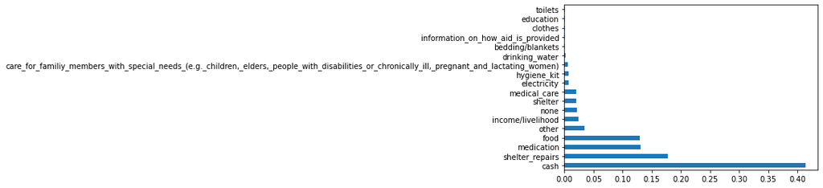

```python
df["First priority"] = toLowerCase(df, "First priority")
inspect("First priority")
#Make lower
```

```
------------------------------PRINT ALL AND TYPE-----------------------------------
-------------------------------UNIQUE VALUES---------------------------------------
[nan 'Psychology ' 'Kid_Necessity' 'Glass' 'Household_Items'
 'Medications: gentle relief/ chondrovital/ calcium 600 mg/ aspirin avenzor 81 mg/magnesal plus/ diclo-neurobion'
 'Education' 'Rent' 'Cancer' 'Emigration' 'Hearing aids' 'Migration'
 'Earpiece' 'Security' 'Other' "They can't paid the rent" 'حفاضات ' 'None'
 'Job vacancy' 'Baby milk diapers' 'milk and diapers' 'Nothing ' 'Nothing'
 'He needs nothing ' 'No need' 'Baby kits' 'School payments'
 'Cash for schools' 'الولادة' 'لا شيء' '.' 'مشكلة مزمنة في العين' '0'
 'مدارس' 'Rent fees' 'Milk for the baby' 'University fees' ' nothing'
 '0000' '000' '00' 'All good' 'ايجار البيت' 'حليب حفاضات ' 'حليب حفاضات'
 'Immigration' 'No needs' 'Car repairing' ' house rent'
 'Milk and diapers for baby of 9months'
 'Medication for epilepsy (baby 7months)' 'Diapers and milk' 'Schools'
 'Education for children' 'Education for the children' 'Children uses'
 'School for the child in the house' 'ايجار ' 'ايجا البيت' 'ايجار المنزل '
 'ايجار' 'فواتير ماي بلديه' 'nothing' 'حليب للأطفال و حفاضات'
 'Job vacancy (civil engineering)' 'House rent' 'School equipments '
 'School for children' 'Traveling' ' .' 'ايجار منزل '
 'بحاجة لاشتارك لداسه اخوها و عمل اخيها الاونلاين و الكهربا بحالة شبه دائما مقطوعه'
 'مكسور ايجار منزل ٦ اشهر ' 'حفاض و حليب' 'ايجار و اشتراكات'
 'They have no needs' 'Education for the kids. ' 'Job'
 'Diapers for elderly ' ' 0' 'Car repair'
 'His partner in home is syrian and has no personal documents'
 'Education for the daughter' 'To pay the rent' 'كل شيء' 'برداية' 'الغاز'
 'Girl,s school'
 'Fix Fridge and Washing Machine that was ruined from the explosion'
 'حليب وحفضات' 'حفضات وحليب' 'None ' 'Education ' 'Television'
 'Diapers/ milk' 'Work for the husband'
 'Education (school) for their small boys' 'A job ' 'Finding a job'
 'School and books' 'Nothing specific'
 'اعطاء المساعدات لناس تستحق المساعده اكثر من اصحاب البناء '
 'الهجره الى بلد اخر' 'Milk and couche' 'Milk and pampers' 'Milk for baby'
 'Rent fees for his wife' 'Electricity fees' 'Refuse to answer'
 'Giving birth' 'Work' 'Diapers' 'Apartment rent'
 'Apartment rent and clothes' 'حفاضات حليب' 'سفر'
 'milk for kids, oil, beans' 'Dont need ' 'Diapers and baby milk'
 'Diapers milk' 'Diapers milk for kids' 'Renting fees'
 'Diapers and milk (nursey 2)' 'حفاضات' 'Nothing specific ' 'العمل' 'عمل'
 'Diapers and milk for a year old' 'Cash for rent' 'Milk,diapers'
```

[output cut: 31 more lines]

```
 'Special food for her so who has a physical disability. ( Milk, Castard, Corn Flakes )'
 'Children needs ' 'Home appliances' 'Home fourniture' 'اجار المنزل'
 'حليب للولاد' 'Na' 'تعويضات التصليحات بسبب الانفجار'
 'Milk and diapers for baby' 'قسط الجامعة' 'حفاضات، حليب...'
 'Psychological support for children' 'قسط البيت' 'دفع مستحقات المنزل'
 'التعويضات' 'حليب' 'تعويض الأضرار' 'تعويض الضرر الذي تم اصلاحه'
 'Universities' 'House rent ' 'House rental' 'المدارس' 'تعويض التصليح'
 'حليب الأطفال']
---------------------------NUMBER OF UNIQUE VALUES---------------------------------
272
-------------------------NUMBER OF MISSING VALUES----------------------------------
30320
-------------------------PERCENT OF MISSING VALUES---------------------------------
0.9451666199071044
-------------------------DISTRIBUTION OF VALUES---------------------------------
```

[figure not shown]

```python
inspect("Please specify")
```

```
------------------------------PRINT ALL AND TYPE-----------------------------------
-------------------------------UNIQUE VALUES---------------------------------------
[nan 'none' 'hygiene_kit' 'medication' 'medical_care' 'food'
 'shelter_repairs' 'cash' 'other'
 'care_for_familiy_members_with_special_needs_(e.g._children,_elders,_people_with_disabilities_or_chronically_ill,_pregnant_and_lactating_women)'
 'electricity' 'income/livelihood' 'drinking_water' 'shelter' 'clothes'
 'information_on_how_aid_is_provided' 'bedding/blankets' 'education'
 'toilets']
---------------------------NUMBER OF UNIQUE VALUES---------------------------------
19
-------------------------NUMBER OF MISSING VALUES----------------------------------
2473
-------------------------PERCENT OF MISSING VALUES---------------------------------
0.07709093176221204
-------------------------DISTRIBUTION OF VALUES---------------------------------
```

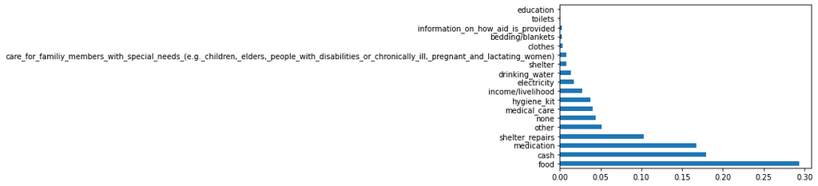

```python
df["Second priority"] = toLowerCase(df, "Second priority")
df["Second priority"] = df["Second priority"].str.strip()
df["Second priority"] = replaceWordSet(df, "Second priority", set(['']), 'none')
inspect("Second priority")
```

```
------------------------------PRINT ALL AND TYPE-----------------------------------
-------------------------------UNIQUE VALUES---------------------------------------
[nan 'Security' 'Medications' 'First Aid' 'Adult diapers' 'psychological '
 'Kid_Necessity' 'Plumbing' 'Rent of the house' 'Rent' 'Hearing aids'
 'Household_Items' 'School and books ' 'None' 'School' 'قرض'
 'دفع اقساط المدرسة' 'AC air condtion' 'Nothing ' 'Noth8ng' '.'
 'Needs nothing ' '0' 'No need' 'Job' 'Nothing' 'لا شيء' 'Education'
 'NOTHING' 'Rent fees' '00000' '000' '0000' 'Fix shattered glass' 'tv'
 'glass' 'Fan' 'No needs' 'Fridge' 'Milk and diapers' 'Baby milk/diabers'
 'Milk 4 year old girl' 'Not in need of anything specific'
 'Nothing specific' 'Other' 'No' 'اعانة اهله الضررين '
 'Cleaning equipement' 'nothing' '٠' 'Migration' 'اجار المنزل' 'Renting'
 'قسط الدراسه' 'Na' 'Fixing the doors ' 'Tv ' 'ايجار فواتير ' 'House rent'
 'ايجار منزل' 'Pay school fees' 'washing machine' 'Nonen' 'لا شيء '
 'Rent fees '
 'Education for the boy 12 years old/ Sister also is handicapped '
 'No Home supplies ' 'لا شئ' 'اغراض اطفال' 'اجار البيت' 'Work'
 'No ,more needw' 'Medication for his wife and mother' 'Baby formula'
 'Diapers' 'Emigration' 'Electronics for home schooling'
 'Education: school fees' 'None ' 'Loan ' 'Nobe' 'سفر وهجرة' 'Milk'
 'Education ' 'Diapers and baby formula' 'Refuse to answer'
 'Anything for the 2 children - school clothes books...' 'Milk and dipers'
 'حليب اطفال' 'تعليم اطفالهم' 'Diapers and milk' 'Children needs' 'لا شيئ'
 'vitamins for kids, face masks ' 'حفاضات و حليب'
 'Milk for the young children' 'No specific need' 'Tuition for school'
 'Diappers and baby formula milk' 'مدرسة الاولاد' 'School tuition'
 'Home supplies' 'Baby products' 'Bills' 'Khezzen may' 'Lunette'
 'في الخارجية يوجد شادر بحاجة الى اعادة تصليح او اعمار سقف جديد بسبب حاجة صاحب الأسرة الى مساحة الخارجية لضروراته الخاصة '
 'Schools' 'Child needs' 'Any type of work' 'No more needs' 'Cash rent'
 'Non' 'Furniture' 'Vaccination for baby'
 'Milk for his daughter : 4 years' 'Clothes for baby' 'Baby kit'
 'Rent cash' 'Cancer patient. Needs hospitalization' 'University fees'
 'ادوات كهربائية' 'فرن' 'Food medication' ' Refregirator and ghassale'
 'ادوات كهربائية و عفش' '-' 'Home appliances' 'Washing machine'
 'شادر للسقف' 'House hardware' 'فرن غاز' 'أقساط الجامعة' 'Shelter cash'
 'طعام وحليب للاطفال وحفاضات ' 'Laptop' 'School fees ' 'Cleaning material'
 'Home rental ' 'تصليح السيارة العمومية' 'حفاضات وحليب للأطفال'
 'Curtains ' 'Financial aids' 'no' 'حليب وحفاضات لولد عمره سنة '
 'Baby milk and diapers' 'دفع للمدارس' 'Baby formula and diappers'
 'Cash for rent' 'Milk for the baby' 'غير متوفر' 'قسط السيارة '
```

[output cut: 14 more lines]

```
 'حفاضات وحليب' 'Computer ' 'School needs' 'التعليم' 'Ghaseli'
 'حليب و حفاضات للاطفال' 'fridge' 'Walker for a special case person'
 'School things' 'مفصل كتف مستعار ' 'Tv' 'قرطاسية لوازم الonline'
 'psychologist' 'مستلزمات مولود جديد' 'House rental' 'baby dippears'
 'cancer medicine' ' Nothing' 'قسط الجامعة' 'Refrigerator and tv'
 'Legal papers' 'المدارس' 'Couche' 'furniture and home appliances'
 'Milk for kids' 'Baby milk and dipears' 'Bed and matresses ' 'farch bet'
 'farech bet' 'Helper fees' 'Milk for the kids']
---------------------------NUMBER OF UNIQUE VALUES---------------------------------
239
-------------------------NUMBER OF MISSING VALUES----------------------------------
29937
-------------------------PERCENT OF MISSING VALUES---------------------------------
0.9332273449920508
-------------------------DISTRIBUTION OF VALUES---------------------------------
```

[figure not shown]

```python
inspect("Please specify5")
```

```
------------------------------PRINT ALL AND TYPE-----------------------------------
-------------------------------UNIQUE VALUES---------------------------------------
[nan 'None' 'Income/livelihood' 'Food' 'Electricity' 'Medication'
 'Medical_care' 'Cash' 'Drinking_Water' 'Hygiene_Kit' 'Shelter_Repairs'
 'Other' 'Bedding/blankets' 'Drinking_water'
 'Care_for_family_members_with_special_needs_(e.g._children,_elders,_people_with_disabilities_or_chronically_ill,_pregnant_and_lactating_women)'
 'Information_on_how_aid_is_provided' 'Clothes' 'Shelter' 'Education'
 'MEdical_Care' 'Medical_Care'
 'Care_for_familiy_members_with_special_needs_(e.g._children,_elders,_people_with_disabilities_or_chronically_ill,_pregnant_and_lactating_women)'
 'Toilets' 'food' 'cash' 'Medication ' 'Food ' 'Cash ' ' Cash'
 'medication' 'Clothes ' 'clothes' 'food ']
---------------------------NUMBER OF UNIQUE VALUES---------------------------------
33
-------------------------NUMBER OF MISSING VALUES----------------------------------
2782
-------------------------PERCENT OF MISSING VALUES---------------------------------
0.08672340160229433
-------------------------DISTRIBUTION OF VALUES---------------------------------
```

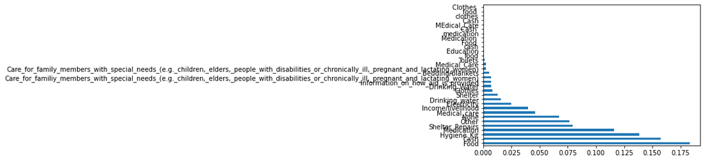

```python
inspect("Third priority")
```

```
------------------------------PRINT ALL AND TYPE-----------------------------------
-------------------------------UNIQUE VALUES---------------------------------------
[nan 'Kid_Items' 'Household_Items' 'Kid_Necessity'
 'Medications: gentle relief/ chondrovital/ calcium 600 mg/ aspirin avenzor 81 mg/magnesal plus/ diclo-neurobion'
 'Glasses' 'School' 'food and income ( very old people in need ) '
 'Dog food' 'Glass for the window ' 'Rent' 'Asthma spray' 'Oxygen machine'
 'Diapers for elderly ' 'Pampers' 'Open Heart Child ' 'Psycological'
 'Fuel' 'Shcool' 'Internet' 'اشتركات' 'None'
 'Repairing the kitchen and toilet' 'none' 'kids necessities'
 'a larger water tank' 'حليب اطفال' 'حفاضات و حليب' 'قرض' 'حليب'
 'رعاية ولدنا' 'Nothing ' 'stationnery school' 'school' 'Nothing' '.'
 'لم يتم التحديد' '0' 'No need' 'اقساط جامعية' 'لا شيء' 'NOTHING'
 ' nothing' '0000' '000' 'Psychologist' 'تامين الايجار '
 'Windows and doors repairing' 'Baby kits' 'Milk and diapers' 'Na'
 'Travel (applied for visa to Brasil)' 'No needs' 'Car fixing'
 'حليب حفاضات' 'Milk and couches' 'Milk' 'وظيفة' 'عمل'
 'أقساط و مدفوعات للشقة و للسيارة' 'فقط طعام و شراب' 'None '
 'Nothing specific' 'Nothing specific ' 'Other' 'School tuitions' 'ايجار '
 'nothing' '٠' 'Sanitation works' 'Diapers, milk...' 'Education'
 'تكاليف المدرسة' 'No another needs' 'No other needs'
 'She doesnt have any more needs' 'ايجار البيت' 'حفاضات و حليب '
 'اصلاح الاجزاء المتضرره من المنزل قبل الشتاء' 'Job for wife'
 'TV / public water ' 'اصلاح الأضرار في المحل التابع له ' 'House rent'
 'Diapers and baby food' 'TV' 'ايجار المنزل' 'School tuition fees'
 'Immigration for other countries' 'Help for education' 'Cleaning kit'
 'They need diapers and food for their babies' 'tv' "Baby's kit"
 'مساعدات خاصة بالحمل ' 'Diapers and milk'
 'Diapers and formula milk for the infant' 'Education for children'
 'Milk and diapers for enfants' 'Psychological ' 'Rent fees'
 ' univerisity fees' 'Baby milk and diapers' 'Baby milk diapers'
 'Expecting a kid soon' 'Finding a job' 'House expenses'
 'TV/ public water' 'تنظيفات' 'تنظيف' 'لا شئ' 'school '
 'Education for the kids' 'لوازم اطفال' 'Cash and psychological aid'
 'عملية ماء زرقاء' 'Cash and food' 'Shop rental' 'Elecricity fees'
 'Education ' 'Food' 'Job' 'X' 'بحاجة ضرورية الى اقسط مدارس وكتب'
 'Furniture' 'Milk for babies' 'Home equipments' 'school tuition'
 'Her mom`s insurance' 'ايجار و دين' 'diapers and child needs'
 'Tanks reservoir' 'Money for college and school fees'
 'Milk and dipers for babies'
 'rented car. it reqiures money to repair it and pay for its rent.'
```

[output cut: 55 more lines]

```
 'Food and milk' 'Chairwheel and holding stick' 'Urgent : اجار بيت'
 'مدخول شهري' 'Eduction' 'طلب هجرة' 'تعوض اصلاحات المنزل' 'School needs'
 'Ghaz' 'احتياجات الابناء' 'electronics' 'ادوات كهربائية ، اثاث منزل'
 'Ghaseli' 'تأمين المياه' 'Care severe injuries' 'نفقات عملية قريبة'
 'Psychological support' 'baby food' 'التعليم' 'Nationality'
 'تعويض التصليحات' 'Eduction ' 'عملية ضرورية' 'Eye surgery'
 'Diapers for oldies' 'Education fees' 'قسط مدرسي' 'Milk and dipears'
 'Dipears and milk' 'Bed' '3afech bet' 'House rent fees' 'المدارس']
---------------------------NUMBER OF UNIQUE VALUES---------------------------------
341
-------------------------NUMBER OF MISSING VALUES----------------------------------
30644
-------------------------PERCENT OF MISSING VALUES---------------------------------
0.9552666853704916
-------------------------DISTRIBUTION OF VALUES---------------------------------
```

[figure not shown]

```python
inspect("Please specify6")
```

# HOUSE DYNAMICS

## Variable 66: How many apartments are on the same floor?

- Remove outliers here

```
------------------------------PRINT ALL AND TYPE-----------------------------------
-------------------------------RANGE OF VALUES---------------------------------------
MIN 0.0
MAX 100002.0
-------------------------NUMBER OF MISSING VALUES----------------------------------
7198
-------------------------PERCENT OF MISSING VALUES---------------------------------
0.2243835531032763
-------------------------DISTRIBUTION OF VALUES---------------------------------
```

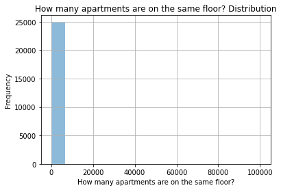

```python
inspect("How many apartments are on the same floor?")
```

## Variable 67: Is there a migrant worker or domenstic helper living with this household?

- Replace missing values with no?

```
------------------------------PRINT ALL AND TYPE-----------------------------------
-------------------------------UNIQUE VALUES---------------------------------------
['no' 'yes' nan]
---------------------------NUMBER OF UNIQUE VALUES---------------------------------
3
-------------------------NUMBER OF MISSING VALUES----------------------------------
8724
-------------------------PERCENT OF MISSING VALUES---------------------------------
0.27195361451416816
-------------------------DISTRIBUTION OF VALUES---------------------------------
```

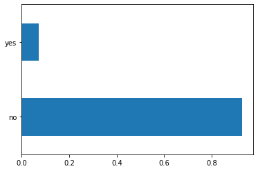

```python
inspect("Is there a migrant worker or domenstic helper living with this household? ")
```

## Variable 68: Have you or any household member damaged/lost any personal documents?

```
------------------------------PRINT ALL AND TYPE-----------------------------------
-------------------------------UNIQUE VALUES---------------------------------------
['yes' 'no' nan]
---------------------------NUMBER OF UNIQUE VALUES---------------------------------
3
-------------------------NUMBER OF MISSING VALUES----------------------------------
8724
-------------------------PERCENT OF MISSING VALUES---------------------------------
0.27195361451416816
-------------------------DISTRIBUTION OF VALUES---------------------------------
```

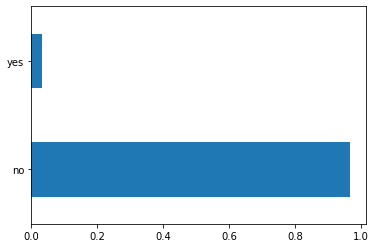

```python
inspect("Have you or any household member damaged/lost any personal documents?")
```

# INFANTS

## Variable 69: Total number of members 0-12 months

- Remove outliers here

```
------------------------------PRINT ALL AND TYPE-----------------------------------
-------------------------------RANGE OF VALUES---------------------------------------
MIN 0.0
MAX 233.0
-------------------------NUMBER OF MISSING VALUES----------------------------------
11513
-------------------------PERCENT OF MISSING VALUES---------------------------------
0.35889522740733815
-------------------------DISTRIBUTION OF VALUES---------------------------------
```

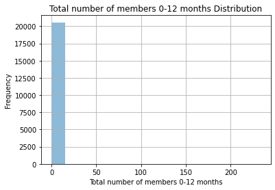

```python
inspect("Total number of members 0-12 months")
```

## Variable 70: Did the children (0-12) receive vaccinations?

- Replace missing values with no?

```
------------------------------PRINT ALL AND TYPE-----------------------------------
-------------------------------UNIQUE VALUES---------------------------------------
[nan 'yes' 'no']
---------------------------NUMBER OF UNIQUE VALUES---------------------------------
3
-------------------------NUMBER OF MISSING VALUES----------------------------------
31042
-------------------------PERCENT OF MISSING VALUES---------------------------------
0.9676735559088501
-------------------------DISTRIBUTION OF VALUES---------------------------------
```

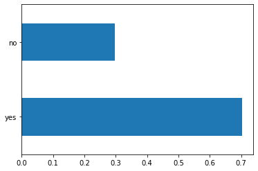

```python
inspect("Did the children (0-12) receive vaccinations?")
```

## Variable 71: Number of children not planning on going to school (despite being school aged)

```
------------------------------PRINT ALL AND TYPE-----------------------------------
-------------------------------RANGE OF VALUES---------------------------------------
MIN 0.0
MAX 4.0
-------------------------NUMBER OF MISSING VALUES----------------------------------
7121
-------------------------PERCENT OF MISSING VALUES---------------------------------
0.22198322890364414
-------------------------DISTRIBUTION OF VALUES---------------------------------
```

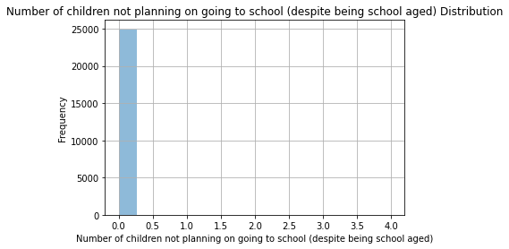

```python
inspect("Number of children not planning on going to school (despite being school aged)")
```

# SAFETY

## Variable 72, 73: How has the Beirut explosion affected you and your household? (select all that apply) | Other, please specify7

- Select all that apply? Should we replace this with a score? Or maybe divide into many columns?
- Other column has over 99% missing values. Should we remove this?

```
------------------------------PRINT ALL AND TYPE-----------------------------------
-------------------------------UNIQUE VALUES---------------------------------------
[nan 'psychological_distress' 'physical_injury,psychological_distress'
 'psychological_distress,physical_injury' 'psychological_distress,hosting'
 'missing_family_member' 'other' 'physical_injury'
 'physical_injury,other,psychological_distress'
 'psychological_distress,other' 'hosting,psychological_distress'
 'other,psychological_distress'
 'physical_injury,psychological_distress,hosting' 'other,physical_injury'
 'hosting' 'physical_injury,other' 'physical_injury,hosting'
 'other,hosting' 'psychological_distress,physical_injury,other']
---------------------------NUMBER OF UNIQUE VALUES---------------------------------
19
-------------------------NUMBER OF MISSING VALUES----------------------------------
31744
-------------------------PERCENT OF MISSING VALUES---------------------------------
0.9895570310795224
-------------------------DISTRIBUTION OF VALUES---------------------------------
```

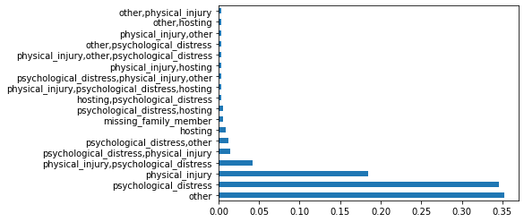

```python
inspect("How has the Beirut explosion affected you and your household? (select all that apply)")
# Since people can choose more than one option, its taking each combination of options as a different value
```

```
------------------------------PRINT ALL AND TYPE-----------------------------------
-------------------------------UNIQUE VALUES---------------------------------------
[nan 'None' 'Home damage' 'Fear in the Children' 'Fear'
 'unjuries member family' 'Psychologically' 'Asthma crisis' 'Objects'
 'Lost some material like washing machine' 'غير متواجدين في البيت'
 'Broken glass ' 'Walls' 'غير قادر على أكل الطعام']
---------------------------NUMBER OF UNIQUE VALUES---------------------------------
14
-------------------------NUMBER OF MISSING VALUES----------------------------------
31974
-------------------------PERCENT OF MISSING VALUES---------------------------------
0.9967268306368653
-------------------------DISTRIBUTION OF VALUES---------------------------------
```

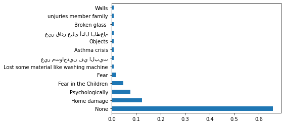

```python
replacement_bags_pairs = {"None": set(['لاشيء ', 'Nothing ', 'None', 'لا يوجد ', 'لا ضرر', 'ال شئ', 'لاشي', 'لا أضرار', 'لا اضرار','No one', 'No damage', 'none', 'none ', 'Nothing', 'لا شيئ', 'لا يوجد' ,'لا يوجد', 'لا احد', ' nothing']),
                          'Home damage' : set(['أضرار في البيت', 'Housing', 'اضرار منزلية','House damages ', 'Home damage ', 'Only housing']),
                          "Psychologically": set(['psychologically', 'مرض نفسي', 'نفسي','نفسيا', 'مرض نفسية', 'إصابة نفسية']),
                          "Fear in the Children": set(['خوف لدى الابناء', 'خوف لدى الاطفال','الطفلة بحاجة  الي مساعده نفسيه', 'fear for the children', 'مرض نفسي (الأولاد)']),
                          "Fear": set(['feers', 'خوف'])
                          }

for replacement in replacement_bags_pairs.keys():
  wordBag = replacement_bags_pairs[replacement]
  df["Other, please specify7"] = replaceWordSet(df, "Other, please specify7", wordBag, replacement)
inspect("Other, please specify7")
```

## Variable 74: Question about protection safety and security: Do you have any concerns about your protection/safety?

- Replace missing values (98.9%) with NaN or no?

```
------------------------------PRINT ALL AND TYPE-----------------------------------
-------------------------------UNIQUE VALUES---------------------------------------
[nan 'no' 'yes']
---------------------------NUMBER OF UNIQUE VALUES---------------------------------
3
-------------------------NUMBER OF MISSING VALUES----------------------------------
31745
-------------------------PERCENT OF MISSING VALUES---------------------------------
0.9895882041210761
-------------------------DISTRIBUTION OF VALUES---------------------------------
```

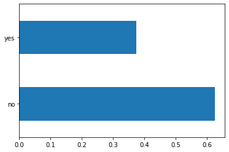

```python
inspect("Question about protection safety and security: Do you have any concerns about your protection/safety? ")
```

## Variable 75: Have you or anyone you know reported sexual or gender based violence/ abuse/ exploitation?

- Replace missing values?

```
------------------------------PRINT ALL AND TYPE-----------------------------------
-------------------------------UNIQUE VALUES---------------------------------------
[nan 'no' 'yes']
---------------------------NUMBER OF UNIQUE VALUES---------------------------------
3
-------------------------NUMBER OF MISSING VALUES----------------------------------
31745
-------------------------PERCENT OF MISSING VALUES---------------------------------
0.9895882041210761
-------------------------DISTRIBUTION OF VALUES---------------------------------
```

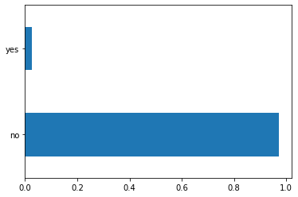

```python
inspect("Have you or anyone you know reported sexual or gender based violence/ abuse/ exploitation?")
```

## Variable 76: Does the house/appartment allow for privacy and safety?

- Also must replace missng values

```
------------------------------PRINT ALL AND TYPE-----------------------------------
-------------------------------UNIQUE VALUES---------------------------------------
[nan 'yes' 'no']
---------------------------NUMBER OF UNIQUE VALUES---------------------------------
3
-------------------------NUMBER OF MISSING VALUES----------------------------------
31754
-------------------------PERCENT OF MISSING VALUES---------------------------------
0.9898687614950591
-------------------------DISTRIBUTION OF VALUES---------------------------------
```

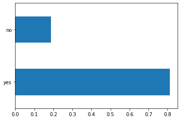

```python
inspect("Does the house/appartment allow for privacy and safety? ")
```

# OCCUPANTS DETAILS (BY GENDER)

## Variable 77: Total number of apartments in the building

- Remove outliers here

```
------------------------------PRINT ALL AND TYPE-----------------------------------
-------------------------------RANGE OF VALUES---------------------------------------
MIN 0.0
MAX 423.0
-------------------------NUMBER OF MISSING VALUES----------------------------------
7837
-------------------------PERCENT OF MISSING VALUES---------------------------------
0.24430312665606782
-------------------------DISTRIBUTION OF VALUES---------------------------------
```

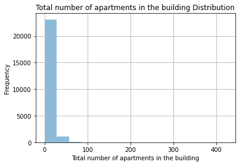

```python
inspect("Total number of apartments in the building")
```

## Variable 78: Total number of male members living now under the same roof (INCLUDING Head of Household)

- Remove outliers

```
------------------------------PRINT ALL AND TYPE-----------------------------------
-------------------------------RANGE OF VALUES---------------------------------------
MIN 0.0
MAX 211.0
-------------------------NUMBER OF MISSING VALUES----------------------------------
9002
-------------------------PERCENT OF MISSING VALUES---------------------------------
0.2806197200660869
-------------------------DISTRIBUTION OF VALUES---------------------------------
```

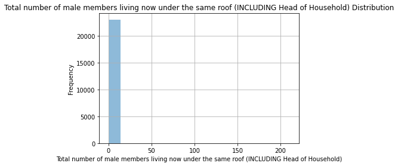

```python
inspect("Total number of male members living now under the same roof (INCLUDING Head of Household)")
```

## Variable 79: Total number of female members living now under the same roof (INCLUDING Head of Household)

- Remove outliers

```
------------------------------PRINT ALL AND TYPE-----------------------------------
-------------------------------RANGE OF VALUES---------------------------------------
MIN 0.0
MAX 23.0
-------------------------NUMBER OF MISSING VALUES----------------------------------
9002
-------------------------PERCENT OF MISSING VALUES---------------------------------
0.2806197200660869
-------------------------DISTRIBUTION OF VALUES---------------------------------
```

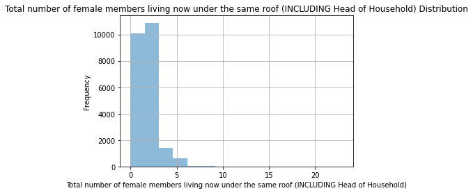

```python
inspect("Total number of female members living now under the same roof (INCLUDING Head of Household)")
```

## Variable 80: Number Male chronically ill people/with critical medical conditions

- Remove outliers
- Replace missing with 0?

```
------------------------------PRINT ALL AND TYPE-----------------------------------
-------------------------------RANGE OF VALUES---------------------------------------
MIN 0.0
MAX 22.0
-------------------------NUMBER OF MISSING VALUES----------------------------------
19389
-------------------------PERCENT OF MISSING VALUES---------------------------------
0.6044141026839989
-------------------------DISTRIBUTION OF VALUES---------------------------------
```

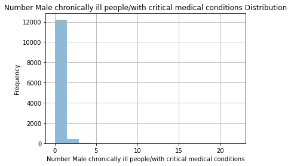

```python
inspect("Number Male chronically ill people/with critical medical conditions")
```

## Variable 81: Number Female chronically ill people/with critical medical conditions

- Remove outliers
- Replace missing with 0?

```
------------------------------PRINT ALL AND TYPE-----------------------------------
-------------------------------RANGE OF VALUES---------------------------------------
MIN 0.0
MAX 110.0
-------------------------NUMBER OF MISSING VALUES----------------------------------
19144
-------------------------PERCENT OF MISSING VALUES---------------------------------
0.5967767075033511
-------------------------DISTRIBUTION OF VALUES---------------------------------
```

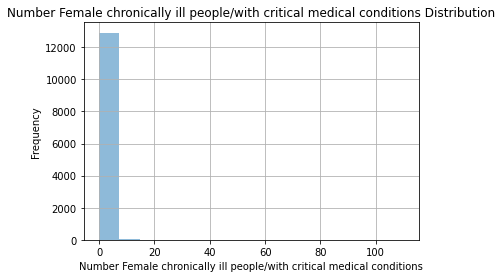

```python
inspect("Number Female chronically ill people/with critical medical conditions")
```

## Variable 82: Number of Male with non-disaster related physical and permanent disability

- Remove outliers
- Replace missing with 0?

```
------------------------------PRINT ALL AND TYPE-----------------------------------
-------------------------------RANGE OF VALUES---------------------------------------
MIN 0.0
MAX 8.0
-------------------------NUMBER OF MISSING VALUES----------------------------------
29745
-------------------------PERCENT OF MISSING VALUES---------------------------------
0.9272421210137474
-------------------------DISTRIBUTION OF VALUES---------------------------------
```

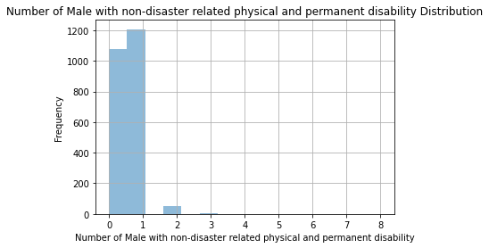

```python
inspect("Number of Male with non-disaster related physical and permanent disability")
```

## Variable 83: Number of Female with non-disaster related physical and permanent disability

- Remove outliers
- Replace missing with 0?

```
------------------------------PRINT ALL AND TYPE-----------------------------------
-------------------------------RANGE OF VALUES---------------------------------------
MIN 0.0
MAX 10.0
-------------------------NUMBER OF MISSING VALUES----------------------------------
29740
-------------------------PERCENT OF MISSING VALUES---------------------------------
0.927086255805979
-------------------------DISTRIBUTION OF VALUES---------------------------------
```

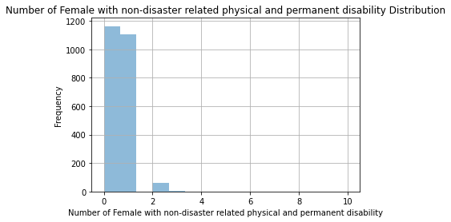

```python
inspect("Number of Female with non-disaster related physical and permanent disability")
```

## Variable 84: Number of Male with disaster related physical and permanent disability

- Remove outliers
- Replace negative values with 0
- Replace missing with 0?

```
------------------------------PRINT ALL AND TYPE-----------------------------------
-------------------------------RANGE OF VALUES---------------------------------------
MIN -1.0
MAX 9.0
-------------------------NUMBER OF MISSING VALUES----------------------------------
29882
-------------------------PERCENT OF MISSING VALUES---------------------------------
0.9315128277065994
-------------------------DISTRIBUTION OF VALUES---------------------------------
```

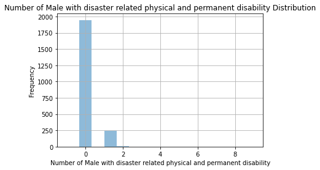

```python
inspect("Number of Male with disaster related physical and permanent disability")
# Negative values
```

## Variable 85: Number of Female with disaster related physical and permanent disability

```
------------------------------PRINT ALL AND TYPE-----------------------------------
-------------------------------RANGE OF VALUES---------------------------------------
MIN 0.0
MAX 10.0
-------------------------NUMBER OF MISSING VALUES----------------------------------
29880
-------------------------PERCENT OF MISSING VALUES---------------------------------
0.931450481623492
-------------------------DISTRIBUTION OF VALUES---------------------------------
```

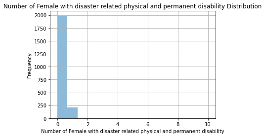

```python
inspect("Number of Female with disaster related physical and permanent disability")
```

## Variable 86: How many Male members need medication?

```
------------------------------PRINT ALL AND TYPE-----------------------------------
-------------------------------RANGE OF VALUES---------------------------------------
MIN 0.0
MAX 9.0
-------------------------NUMBER OF MISSING VALUES----------------------------------
23050
-------------------------PERCENT OF MISSING VALUES---------------------------------
0.7185386078119642
-------------------------DISTRIBUTION OF VALUES---------------------------------
```

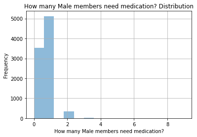

```python
inspect("How many Male members need medication?")
```

## Variable 87: How many Female members need medication?

- Remove outliers
- Replace missing with 0?

```
------------------------------PRINT ALL AND TYPE-----------------------------------
-------------------------------RANGE OF VALUES---------------------------------------
MIN 0.0
MAX 15.0
-------------------------NUMBER OF MISSING VALUES----------------------------------
22776
-------------------------PERCENT OF MISSING VALUES---------------------------------
0.7099971944262602
-------------------------DISTRIBUTION OF VALUES---------------------------------
```

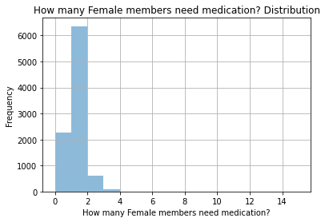

```python
inspect("How many Female members need medication?")
```

## Variable 88: How many Male members generated income in the last 2 weeks

```
------------------------------PRINT ALL AND TYPE-----------------------------------
-------------------------------RANGE OF VALUES---------------------------------------
MIN -1.0
MAX 2500000.0
-------------------------NUMBER OF MISSING VALUES----------------------------------
10498
-------------------------PERCENT OF MISSING VALUES---------------------------------
0.3272545902303688
-------------------------DISTRIBUTION OF VALUES---------------------------------
```

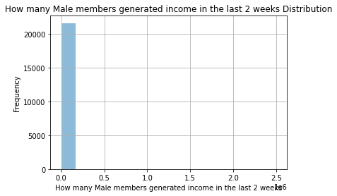

```python
inspect("How many Male members generated income in the last 2 weeks")
#Negative values
```

## Variable 89: How many Female members generated income in the last 2 weeks

```
------------------------------PRINT ALL AND TYPE-----------------------------------
-------------------------------RANGE OF VALUES---------------------------------------
MIN 0.0
MAX 1000000.0
-------------------------NUMBER OF MISSING VALUES----------------------------------
11344
-------------------------PERCENT OF MISSING VALUES---------------------------------
0.35362698338476883
-------------------------DISTRIBUTION OF VALUES---------------------------------
```

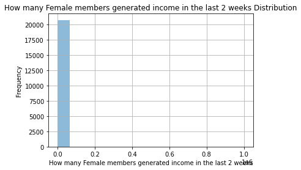

```python
inspect("How many Female members generated income in the last 2 weeks")
```

## Variable 90: Specify other partner

```
------------------------------PRINT ALL AND TYPE-----------------------------------
-------------------------------UNIQUE VALUES---------------------------------------
['ACF' nan 'Nabaa' 'Acf' 'bau and nabaa' '0' 'Iom' 'IOM' 'نبع' 'مبع' 'Ikm'
 'Nabeaa' 'ION' 'Bassel and dayane' 'Nbeaa' 'IoM' 'Gvc' 'GVC'
 'Rana Shreif' 'نبع ' 'Naba’a' 'Naba’a ' 'Io.' 'Nazlia ismail'
 'Borj hammoud' 'Nadine Majd' 'نيع' "Naba'a " "Naba'a" 'IOM ' 'Sin el fil'
 'وسيلة أحمد حمد ' 'برج حمود' 'Sheild' 'ACf' 'Iom ' 'Sheild '
 'Sheild team 2' 'Ion' 'Chahnaz ahmd' 'ACC' 'Iomo' 'Shield'
 'Bourj hammoud' 'KOM' 'Oim' 'Sheildteam7' 'Nehmat bakhos' 'sheild'
 'Narmin' 'Narmine' 'Sheildteam3' ' iom' 'Bilal' 'Sheilf' 'عبدالله عبيد'
 'iom' 'سن الفيل' 'Sheild*' 'سن الفيل ' 'Basta' 'Delta' 'gvc' 'geitawi'
 'delta' 'Msaytbe' 'Iomالبسطة' 'Delga' 'Delfa' 'Delta ' 'SADA'
 'Boroj abi haidar' 'DELTA' 'Dahyeh']
---------------------------NUMBER OF UNIQUE VALUES---------------------------------
74
-------------------------NUMBER OF MISSING VALUES----------------------------------
29722
-------------------------PERCENT OF MISSING VALUES---------------------------------
0.926525141058013
-------------------------DISTRIBUTION OF VALUES---------------------------------
```

[figure not shown]

```python
inspect("Specify other partner")
#Spelling and language
```

## Variable 91, 92: Creation Date | Creator

```python
# inspect("CreationDate")
```

```
------------------------------PRINT ALL AND TYPE-----------------------------------
-------------------------------UNIQUE VALUES---------------------------------------
['acfspain.guest' 'unhabitat.guest' 'pcpm.guest' 'youth1.lrc' 'youth.lrc'
 'dms.lrc' 'youth2.lrc' 'savethechildren.guest' 'medair.guest'
 'intersos.guest' 'iom.guest' 'lebrelief.guest' 'solidarite.guest'
 'iom1.guest' 'acted.guest' 'cww.guest' 'gvc.guest' 'nawaya.guest'
 'WFP.guest' 'puami.guest' 'dms1.lrc' 'dmu.beirut' 'dmu.hasbaya'
 'dmu.akkar' 'dmu.cpp' 'dmu.keserwan' 'youth4.lrc' nan 'LRC.GIS'
 'youth3.lrc' 'FW.Ibrahim']
---------------------------NUMBER OF UNIQUE VALUES---------------------------------
31
-------------------------NUMBER OF MISSING VALUES----------------------------------
1
-------------------------PERCENT OF MISSING VALUES---------------------------------
3.1173041553664394e-05
-------------------------DISTRIBUTION OF VALUES---------------------------------
```

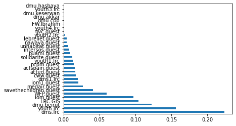

```python
inspect("Creator")
```